# Titanic: Machine Learning from Disaster

Sumer Bangera

16 October 2018

# Set Sail - Loading the data sets

```r
train <- read.csv("train.csv", header = TRUE)

test <- read.csv("test.csv", header = TRUE)

str(train) # To explore the data frame and its data types
```

```
## 'data.frame':    891 obs. of  12 variables:
##  $ PassengerId: int  1 2 3 4 5 6 7 8 9 10 ...
##  $ Survived   : int  0 1 1 1 0 0 0 0 1 1 ...
##  $ Pclass     : int  3 1 3 1 3 3 1 3 3 2 ...
##  $ Name       : Factor w/ 891 levels "Abbing, Mr. Anthony",..: 109 191 358 277 16 559 520 629 417 581 ...
##  $ Sex        : Factor w/ 2 levels "female","male": 2 1 1 1 2 2 2 2 1 1 ...
##  $ Age        : num  22 38 26 35 35 NA 54 2 27 14 ...
##  $ SibSp      : int  1 1 0 1 0 0 0 3 0 1 ...
##  $ Parch      : int  0 0 0 0 0 0 0 1 2 0 ...
##  $ Ticket     : Factor w/ 681 levels "110152","110413",..: 524 597 670 50 473 276 86 396 345 133 ...
##  $ Fare       : num  7.25 71.28 7.92 53.1 8.05 ...
##  $ Cabin      : Factor w/ 148 levels "","A10","A14",..: 1 83 1 57 1 1 131 1 1 1 ...
##  $ Embarked   : Factor w/ 4 levels "","C","Q","S": 4 2 4 4 4 3 4 4 4 2 ...
```

```r
str(test)
```

```
## 'data.frame':    418 obs. of  11 variables:
##  $ PassengerId: int  892 893 894 895 896 897 898 899 900 901 ...
##  $ Pclass     : int  3 3 2 3 3 3 3 2 3 3 ...
##  $ Name       : Factor w/ 418 levels "Abbott, Master. Eugene Joseph",..: 210 409 273 414 182 370 85 58 5 104 ...
##  $ Sex        : Factor w/ 2 levels "female","male": 2 1 2 2 1 2 1 2 1 2 ...
##  $ Age        : num  34.5 47 62 27 22 14 30 26 18 21 ...
##  $ SibSp      : int  0 1 0 0 1 0 0 1 0 2 ...
##  $ Parch      : int  0 0 0 0 1 0 0 1 0 0 ...
##  $ Ticket     : Factor w/ 363 levels "110469","110489",..: 153 222 74 148 139 262 159 85 101 270 ...
##  $ Fare       : num  7.83 7 9.69 8.66 12.29 ...
##  $ Cabin      : Factor w/ 77 levels "","A11","A18",..: 1 1 1 1 1 1 1 1 1 1 ...
##  $ Embarked   : Factor w/ 3 levels "C","Q","S": 2 3 2 3 3 3 2 3 1 3 ...
```

# Exploring the survival and casualty rates

```r
table(train$Survived)   # Survival rates in absolute numbers
```

```
##
##   0   1
## 549 342
```

```r
prop.table(table(train$Survived))   # Survival rates in proportions
```

```
##
##         0         1
## 0.6161616 0.3838384
```

# Two-way comparison: Sex and Survived

Notes: We consider gender to be an important variable that can influence survival chances of the individual. Therefore, we compare the two by creating the following table:

```r
table(train$Sex, train$Survived) # Two-way comparison in absolute values
```

```
##
##            0   1
##   female  81 233
##   male   468 109
```

```r
prop.table(table(train$Sex, train$Survived), margin = 1)  # Two-way comparison: row-wise proportions
```

```
##
##                  0         1
##   female 0.2579618 0.7420382
##   male   0.8110919 0.1889081
```

Notes: For two-way comparison we need to specify whether we want row-wise or column-wise proportions. This can be done by setting the second argument of the prop.table() i.e. margin() as ‘1’ for row-wise and ‘2’ for column-wise proportions

# Does age play a role?

Notes: Another variable that could influence survival is age: it’s that probable children were saved first. We can test this by creating a new column with a categorical variable Child using ‘$’ as follows:

```r
train$Child <- NA
```

Now, we provide the values for each observation (i.e., row) based on the age of the passenger. We can use a boolean test inside square brackets for this as follows:

```r
train$Child[train$Age < 18] <- 1  # If the passenger's Age is < 18 years, we assign 1
train$Child[train$Age >= 18] <- 0 # If the passenger's Age is >= 18 years, we assign 0
```

Since our Child column is ready, we do a two-way comparison on the number of children vs adults that survived, in row-wise proportions using the following code:

```r
prop.table(table(train$Child, train$Survived), margin = 1)
```

```
##
##             0         1
##   0 0.6189684 0.3810316
##   1 0.4601770 0.5398230
```

# Making the first predictions

Notes: In one of the previous exercises above using the train data, we observed that females had over a 50% chance of surviving and males had less than a 50% chance of surviving. Hence, we could use this information for our first prediction assuming: all females survive while all males die. We use the test data to validate our predictions.

```r
test_one <- test #Creating a copy of test data

test_one$Survived <- 0 #Initializing new variable in test_one
test_one$Survived[test_one$Sex == 'female'] <- 1
```

# Saving the predictions made into a CSV file

Notes: We use the write.csv() function to save the data frame ‘test_one’ into a csv file as follows:

```r
write.csv(test_one, file = 'test_one.csv', row.names = FALSE)
```

# Decision Trees

Notes: In the previous exercises we did all the slicing and dicing manually to find subsets that have a higher chance of surviving. A decision tree automates this process and outputs a flowchart-like structure that is easy to interpret.

Conceptually, the decision tree algorithm starts with all the data at the root node and scans all the variables for the best one to split on. Once a variable is chosen, we do the split and go down one level (or one node) and repeat. The final nodes at the bottom of the decision tree are known as terminal nodes, and the majority vote of the observations in that node determine how to predict for new observations that end up in that terminal node.

# Creating a flowchart in R

Notes: To create a decision tree, we make use of R’s ‘rpart’ package and rpart() fucntion as follows:

```r
library('rpart')
?rpart()    # Check the arguments the function rpart() takes
```

```
## starting httpd help server ... done
```

```r
my_tree <- rpart(Survived ~ Pclass + Sex + Age + SibSp + Parch + Fare + Embarked,
                 data = train,
                 method = 'class')  # We use method = 'class' as our prediction will be a categorical variable
```

# Visualizing the flowchart

Notes: We can visualize the flowchart created above either by using some basic functions or using some advanced libararies.

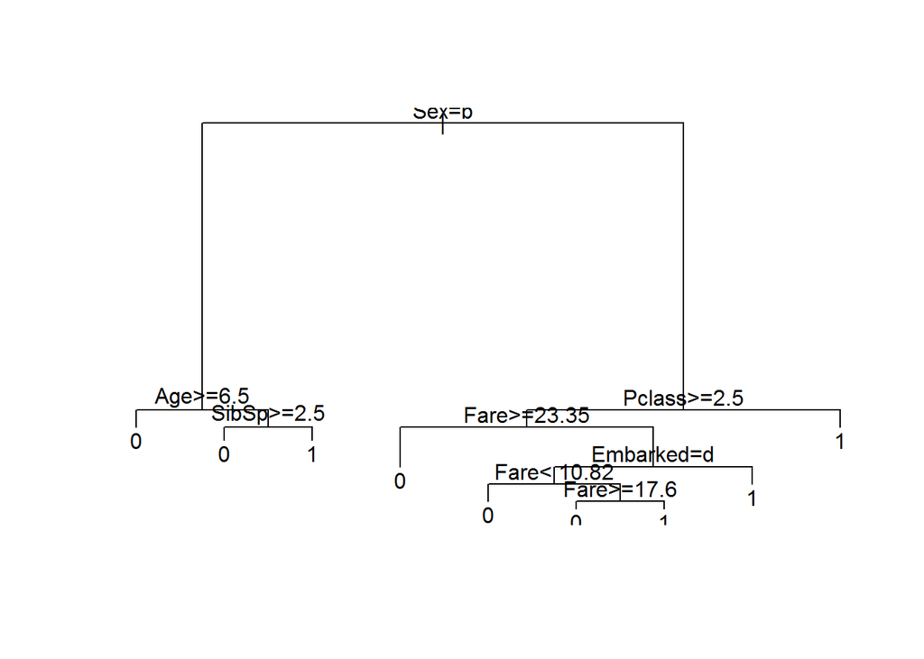

```r
# Visualize the decision tree using plot() and text()
plot(my_tree)
text(my_tree)
```

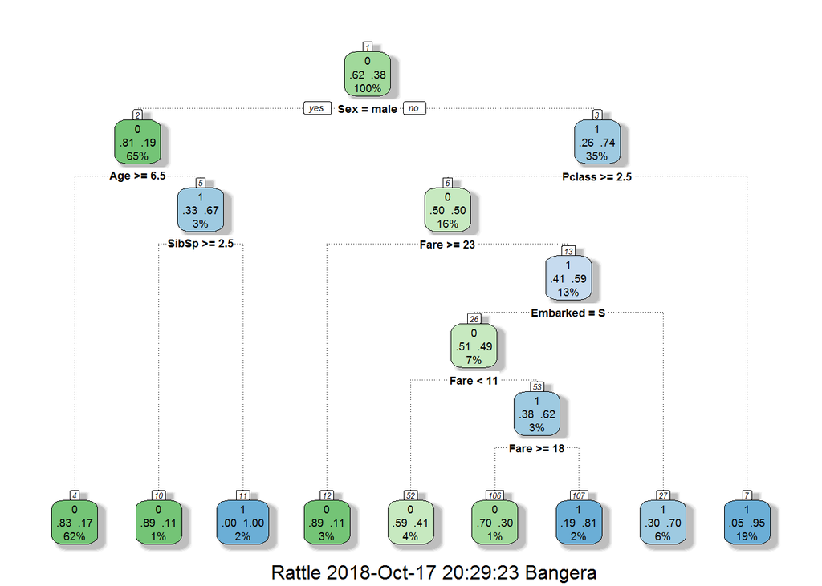

```r
# Load in the packages to build a fancy plot
library(rattle)
library(rpart.plot)
library(RColorBrewer)

# Building advanced flowcharts
fancyRpartPlot(my_tree)
```

# Predicting the survivors using th decision tree

Notes: Now that we have a decision tree, we can make use of the predict() function on the ‘test’ data to “generate” our predictions:

```r
my_prediction <- predict(my_tree,
                         newdata = test,
                         type = 'class')
```

# Saving the predictions to a csv file

Notes: Since we only wish to save the 2 columns(unlike with test_one above) into our solution file viz. Passenger ID and the prediction, we use the following code:

```r
my_solution <- data.frame(PassengerID = test$PassengerId, Survived = my_prediction)

write.csv(my_solution, file = 'my_solution.csv', row.names = FALSE)

# row.names = FALSE excludes the additional column of row numbers
```

# Overfitting, the iceberg of decision trees

Notes: We now try to improve the predictions further by employing a more complex model.

In rpart, the amount of detail is defined by two parameters:

1. ‘cp’ determines when the splitting up of the decision tree stops e.g. cp = 0 implies no stopping of splits.
2. ‘minsplit’ determines the minimum amount of observations in a leaf of the tree’

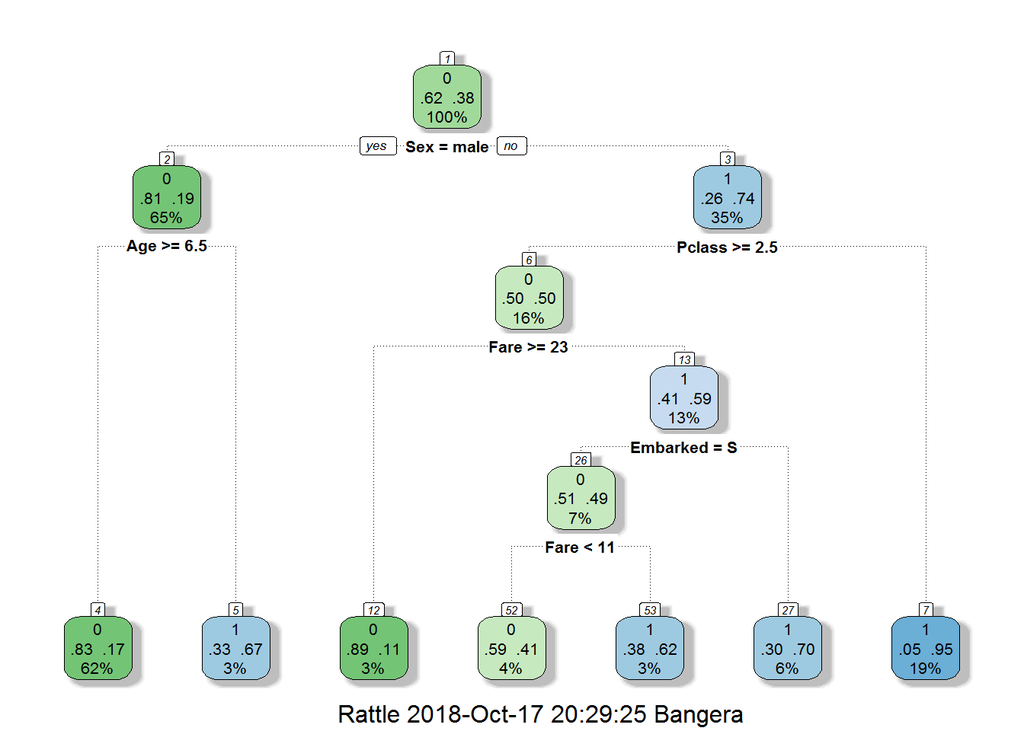

```r
my_tree_two <- rpart(Survived ~ Pclass + Sex + Age + SibSp + Parch + Fare + Embarked,
                     data = train,
                     method = "class",
                     control = rpart.control(minsplit = 50, cp = 0))

fancyRpartPlot(my_tree_two)
```

# Re-engineering Titanic data set

Notes: We now use feature engineering i.e. creatively engineering our own features by combining the different existing variables. We will use feature engineering to create a new variable called family_size

A valid assumption is that larger families need more time to get together on a sinking ship, and hence have less chance of surviving. Family size is determined by the variables SibSp and Parch, which indicate the number of family members a certain passenger is traveling with. So when doing feature engineering, we add the new variable family_size, which is the sum of SibSp and Parch plus one (the observation itself), to the test and train set.

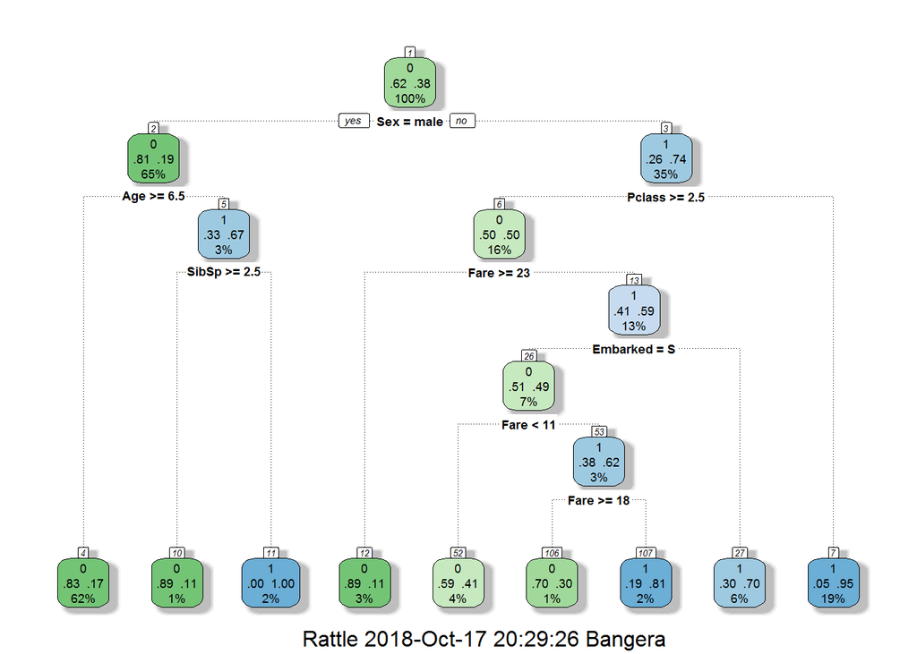

```r
train_two <- train
train_two$family_size <- train_two$SibSp + train_two$Parch + 1

test_two <- train
test_two$family_size <- test_two$SibSp + test_two$Parch + 1


my_tree_three <- rpart(Survived ~ Pclass + Sex + Age + SibSp + Parch + Fare + Embarked + family_size,
                       data = train_two,
                       method = 'class')

fancyRpartPlot(my_tree_three)
```

Note: If we have a close look at the decision tree we can observe that family_size is not included. Apparently other variables played a more important role. This is a part of the game as well. Sometimes things will not turn out as expected.

# Passenger Title and Survival Rate - Creating Title Variable

Notes: If we scroll through the dataset we see many more titles including Miss, Mrs, Master, and even the Countess! Perhaps the persons title might give us a little more insight.

In order to extract these titles to make new variables, we’ll need to perform the same actions on both the training and testing set, so that the features are available for growing our decision trees, and making predictions on the unseen testing data.

```r
# Creating the new variable Title in train data set
train_new <- train

# Extracting passenger titles
train_new$Name <- as.character(train_new$Name) # To convert factors to strings

strsplit(train_new$Name[1], split = '[,.]')[[1]][2] # To check if the formula is working correctly
```

```
## [1] " Mr"
```

```r
# Applying formula to all the rows
train_new$Title <- sapply(train_new$Name, FUN=function(x) {strsplit(x, split='[,.]')[[1]][2]})

# Trimming left and right spaces from Title
train_new$Title <- trimws(train_new$Title, "both")

# Combining some passenger titles

# We use %in% operator to check if a value is part of the vector
train_new$Title[train_new$Title %in% c("Mme", "Mlle")] <- "Mlle"

train_new$Title[train_new$Title %in% c("Capt", "Col", "Don", "Major", "Sir")] <- "Sir"

train_new$Title[train_new$Title %in% c("Jonkheer", "Lady", "Ms", "the Countess", "Dona")] <- "Lady"

# We convert string type back to factor
train_new$Title <- factor(train_new$Title)

# Checking the new titles
table(train_new$Title)
```

```
##
##     Dr   Lady Master   Miss   Mlle     Mr    Mrs    Rev    Sir
##      7      4     40    182      3    517    125      6      7
```

```r
write.csv(train_new, file = 'train_new.csv', row.names = FALSE)
```

```r
# Creating the new variable Title in test data set
test_new <- test

# Extracting passenger titles
test_new$Name <- as.character(test_new$Name) # To convert factors to strings

strsplit(test_new$Name[1], split = '[,.]')[[1]][2] # To check if the formula is working correctly
```

```
## [1] " Mr"
```

```r
# Applying formula to all the rows
test_new$Title <- sapply(test_new$Name, FUN=function(x) {strsplit(x, split='[,.]')[[1]][2]})

# Trimming left and right spaces from Title
test_new$Title <- trimws(test_new$Title, "both")

# combining some passenger titles

# We use %in% operator to check if a value is part of the vector
test_new$Title[test_new$Title %in% c("Mme", "Mlle")] <- "Mlle"

test_new$Title[test_new$Title %in% c("Capt", "Col", "Don", "Major", "Sir")] <- "Sir"

test_new$Title[test_new$Title %in% c("Jonkheer", "Lady", "Ms", "the Countess","Dona")] <- "Lady"

# We convert string type back to factor
test_new$Title <- factor(test_new$Title)

# Checking the new titles
table(test_new$Title)
```

```
##
##     Dr   Lady Master   Miss     Mr    Mrs    Rev    Sir
##      1      2     21     78    240     72      2      2
```

# Passenger Title and Survival Rate - Making Predictions

[figure not shown]

```r
# Creating the decision tree

library(rattle)
library(rpart.plot)
library(RColorBrewer)

my_tree_four <- rpart(Survived ~ Pclass + Sex + Age + SibSp + Parch + Fare + Embarked + Title,
                      data = train_new, method = "class")

# Visualizing my_tree_four
fancyRpartPlot(my_tree_four)
```

```r
# Making predictions
my_prediction <- predict(my_tree_four, test_new, type = "class")

my_solution <- data.frame(PassengerId = test_new$PassengerId, Survived = my_prediction)

# Saving predictions into a csv file
write.csv(my_solution, file = "my_solution.csv", row.names = FALSE)
```

# Random Forest

Notes: Random Forest grows multiple (very deep) classification trees using the training set. At the time of prediction, each tree is used to come up with a prediction and every outcome is counted as a vote. For example, if we have trained 3 trees with 2 saying a passenger in the test set will survive and 1 says he will not, the passenger will be classified as a survivor. This approach of overtraining trees, but having the majority’s vote count as the actual classification decision, avoids overfitting.

However, before starting with the actual analysis, we first need to meet one big condition of Random Forests: no missing values in the data frame.

```r
# We use 'all_data' combined from train and test data for this exercise
all_data <- read.csv('all_data.csv')
# Passenger on row 62 and 830 do not have a value for embarkment.
# Since many passengers embarked at Southampton, we give them the value S.
all_data$Embarked[c(62, 830)] <- "S"

# Factorize embarkment codes.
all_data$Embarked <- factor(all_data$Embarked)

# Passenger on row 1044 has an NA Fare value. Let's replace it with the median fare value.
all_data$Fare[1044] <- median(all_data$Fare, na.rm = TRUE)

# We make a prediction of a passenger's missing Age values using the other variables and a decision tree model
# This time we give method = "anova" since we are predicting a continuous variable

library(rpart)
predicted_age <- rpart(Age ~ Pclass + Sex + SibSp + Parch + Fare + Embarked + Title + family_size,
                       data = all_data[!is.na(all_data$Age),], method = "anova")

all_data$Age[is.na(all_data$Age)] <- predict(predicted_age, all_data[is.na(all_data$Age),])

# Split the data back into a train set and a test set
train <- all_data[1:891,]
test <- all_data[892:1309,]
```

# Random Forest analysis in R

Notes: For a Random Forest analysis in R we make use of the randomForest() function in the randomForest package. Few important points to note about randomForest():

1. First we provide the formula. There is no argument ‘class’ here to inform the function that we’re dealing with predicting a categorical variable, so we need to turn ‘Survived’ into a factor with two levels: as.factor(Survived) ~ Pclass + Sex + Age
2. The data argument takes the train data frame.
3. When we put the importance argument to TRUE we can inspect variable importance.
4. The ntree argument specifies the number of trees to grow. Limit these when having only limited computational power at disposal.
5. To end, since Random Forest uses randomization, we set a seed like this ‘set.seed(111)’ to assure reproducibility of your results.

Once the model is constructed, we can use the prediction function predict().

```r
# Load in the package
library(randomForest)
# Set seed for reproducibility
set.seed(111)

# Apply the Random Forest Algorithm
my_forest <- randomForest(as.factor(Survived) ~ Pclass + Sex + Age + SibSp + Parch + Fare + Embarked + Title,
                          data = train, importance = TRUE, ntree = 1000)

# Make prediction using the 'test' set and not the 'train' set
my_prediction <- predict(my_forest, test)

# Create a data frame with two columns: PassengerId & Survived. Survived contains the predictions
my_solution <- data.frame(PassengerId = test$PassengerId, Survived = my_prediction)

# Write the solution away to a csv file with the name my_solution.csv
write.csv(my_solution, file = "my_solution.csv", row.names = FALSE)
```

# Checking variables that are important

Notes: In the previous step, we set importance = TRUE. We use the following code to check the important variables.

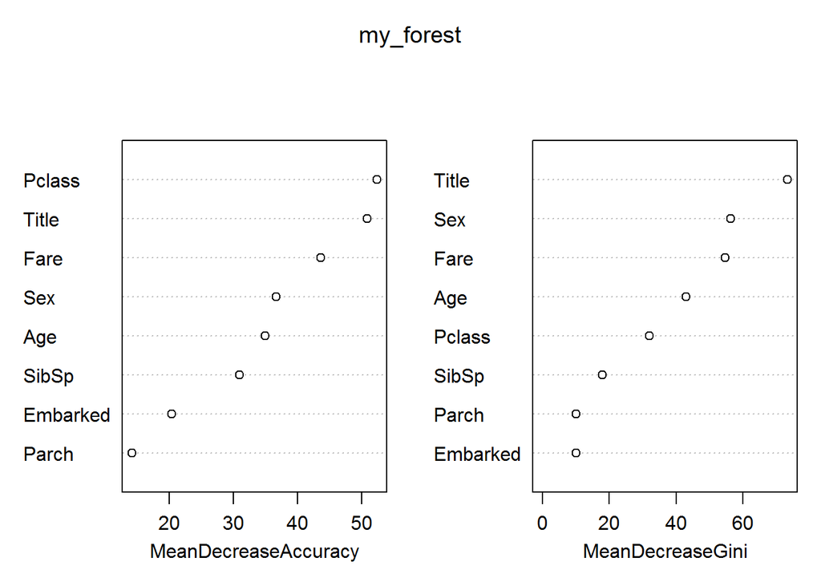

```r
varImpPlot(my_forest)
```